| Ballston Lake | Ballston Lake Improvement Association | Town(s) of Ballston | Saratoga County |
| --- | --- | --- | --- |
| Ballston Lake-shallow site | Ballston Lake Improvement Association | Town(s) of Ballston | Saratoga County |
| Ballston Lake | Ballston Lake Improvement Association | Town(s) of Ballston | Saratoga County |
| Ballston Lake-shallow site | Ballston Lake Improvement Association | Town(s) of Ballston | Saratoga County |

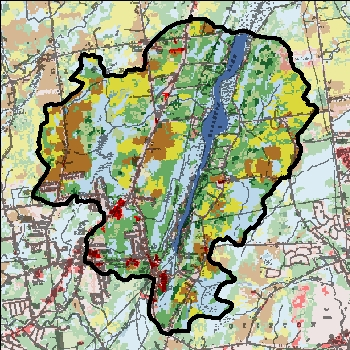

## Ballston Lake – 2018 Sampling Season Results

Open Water Indicators

2018 Sampling Results

Seasonal Change

Season Avg

Decadal Average

Decadal Trend?

Longterm Avg

Longterm Trend?

06-18

07-01

07-15

07-29

08-11

08-26

09-09

09-23

Clarity (m)

2.2

2.2

3.5

2.5

1.4

1.8

1.6

1.4

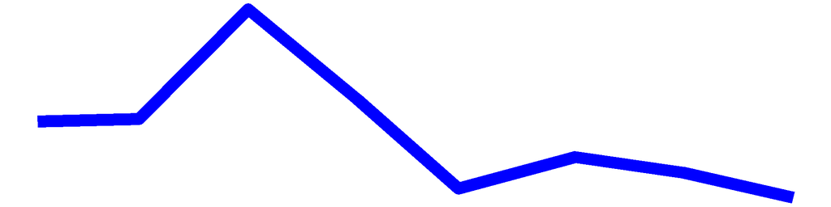

2

1.8

2

Surface TP (mg/L)

0.021

0.027

0.011

0.025

0.023

0.025

0.028

0.026

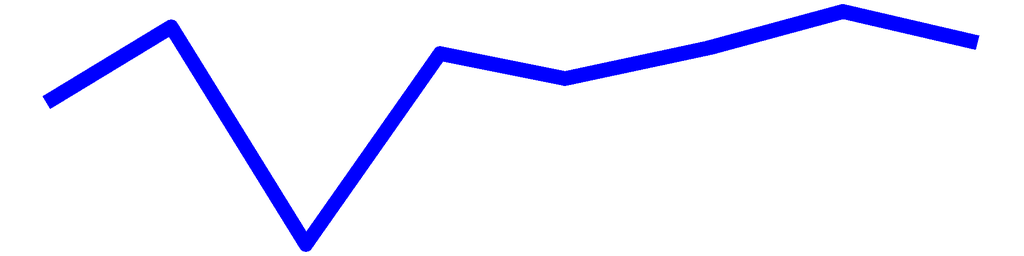

0.024

0.038

0.031

Surface TDP (mg/L)

0.011

0.013

0.015

0.015

0.014

0.009

0.019

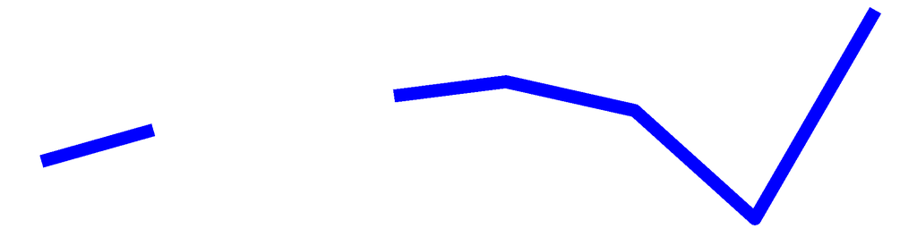

0.014

TN (mg/L)

0.503

0.526

0.457

0.648

0.65

0.532

0.357

0.541

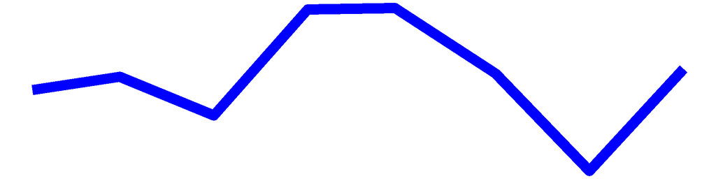

0.527

0.627

0.62

TDN (mg/L)

0.48

0.464

0.426

0.598

0.659

0.503

0.342

0.513

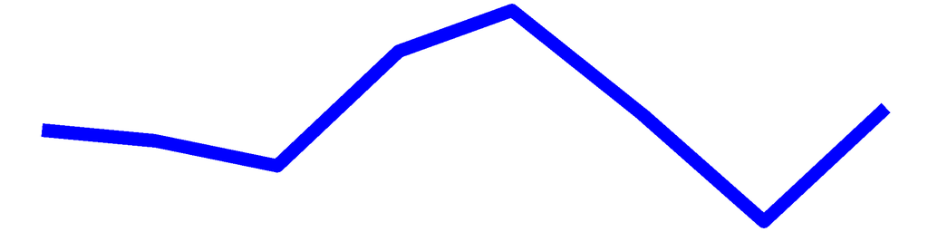

0.498

0.424

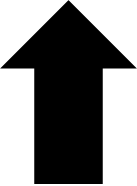

0.424

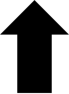

TN:TP

24

20

44

26

28

22

14

21

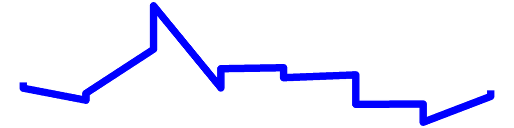

25

19

19

Surface NH3 (mg/L)

0.041

0.042

0.037

0.036

0.051

0.01

0.013

0.032

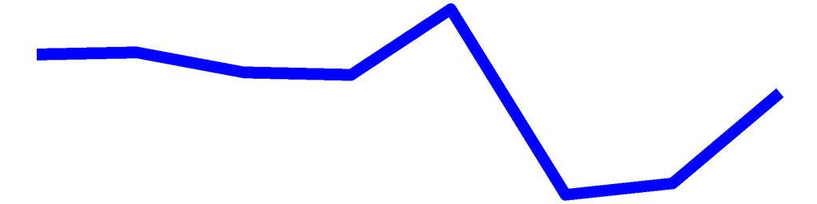

0.033

Chl.a (ug/L)

4.5

3.2

5

6.5

14.7

10.2

5.4

12.2

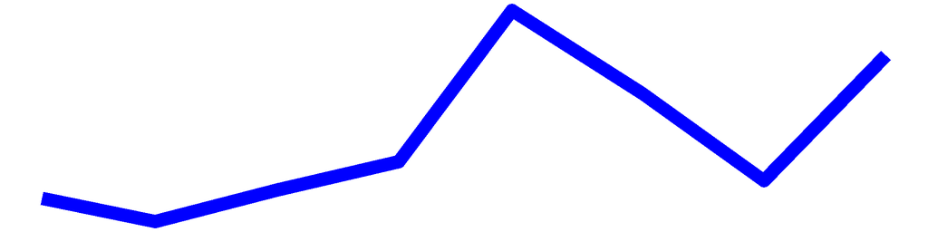

7.5

25.2

19.4

pH

7.6

7.7

7.6

7.6

7.5

7.4

7.5

7.2

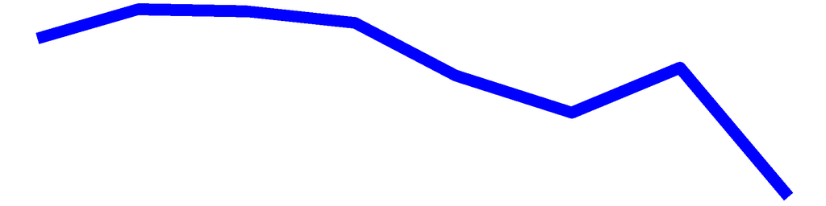

7.5

7.6

7.7

Cond (umho/cm)

506

503

472

497

502

504

692

460

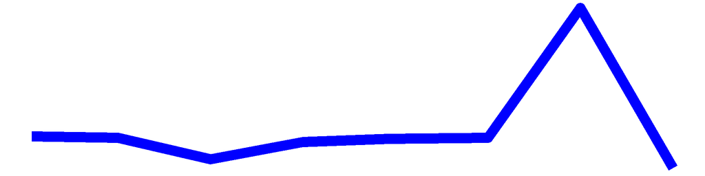

517

384

340

Surface Chloride (mg/L)

74

76

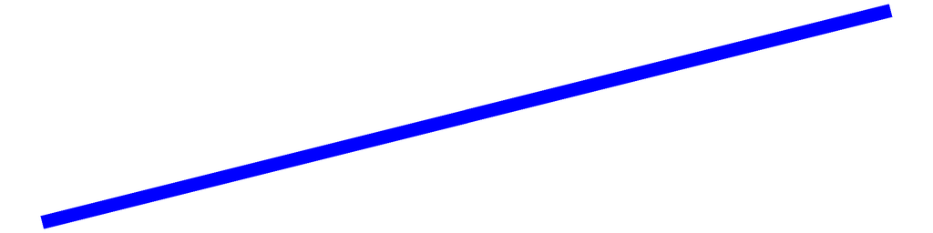

75

62

62

Upper Temp (degC)

23

26

26

26

24

24

21

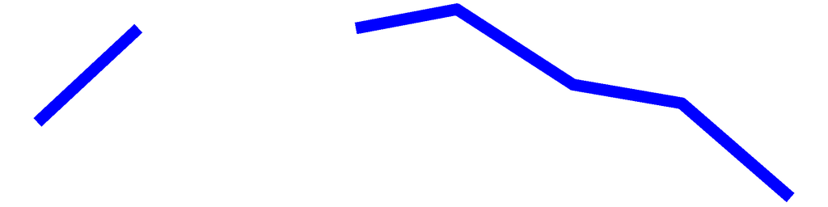

24

24

23

FP BG Chl.a (ug/L)

3.8

1.8

1.4

3.5

15.1

6.5

19.6

15.6

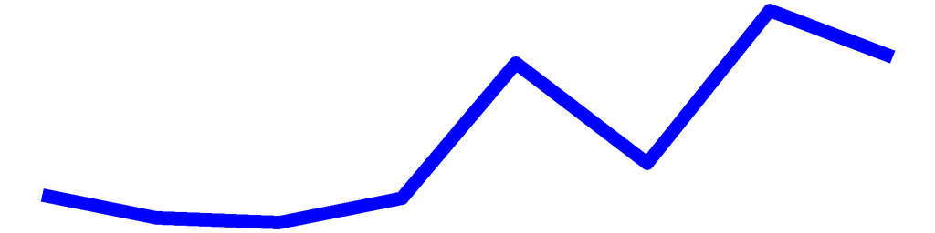

8.4

5

5

### NYHABs notifications

#### Were there any reported HABs this season? **No.**

### Shoreline HAB Sample Dates 2018

There were no shoreline HAB samples taken this season.

### HABs Status

#### Open Water Algae

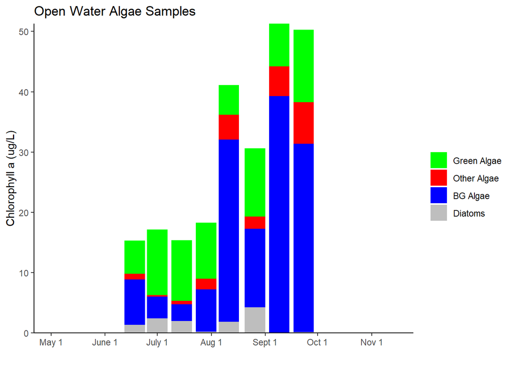

## Ballston Lake Long-Term Trend Analysis

#### Clarity

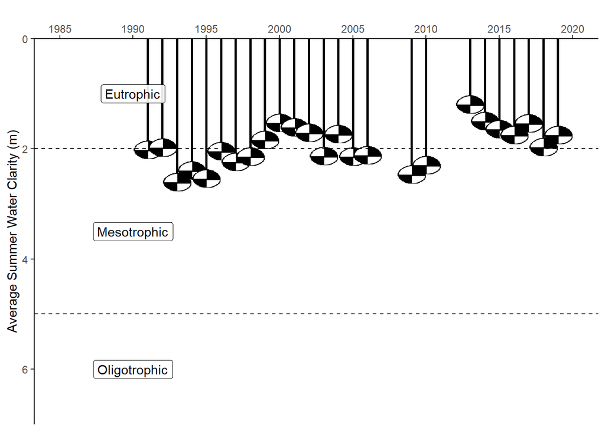

#### Chlorophyll *a*

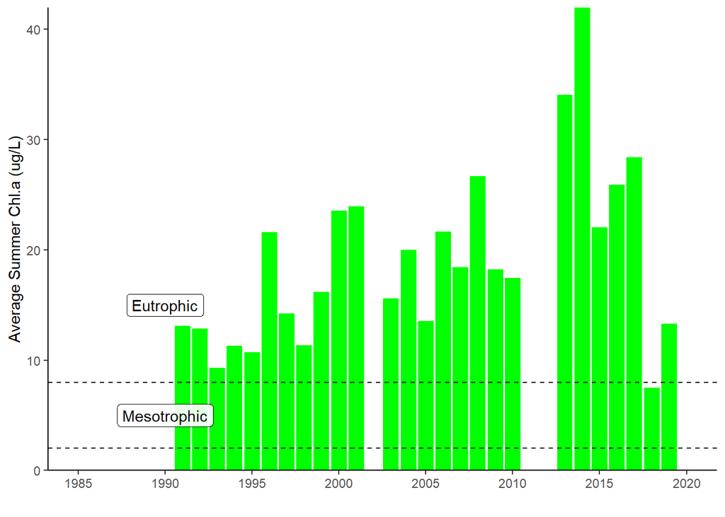

#### Surface and Deep Phosphorus

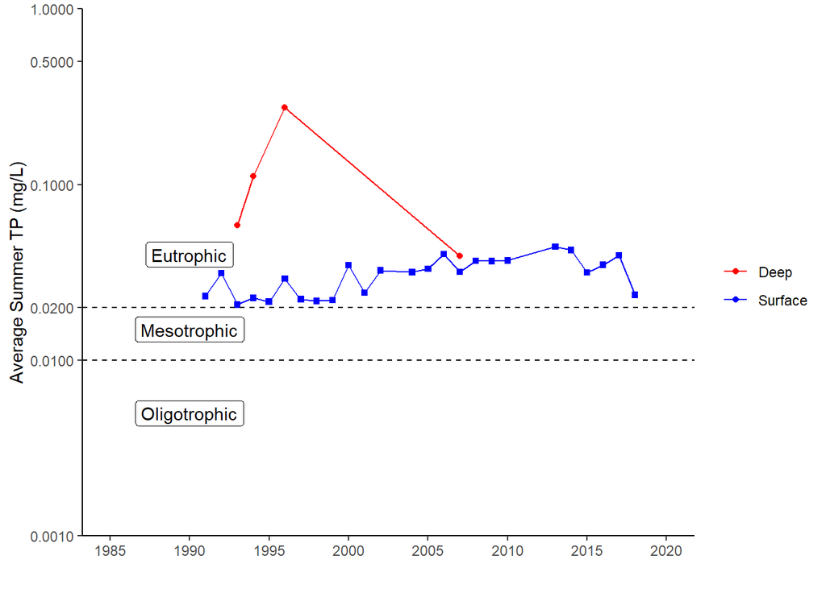

#### Nitrogen

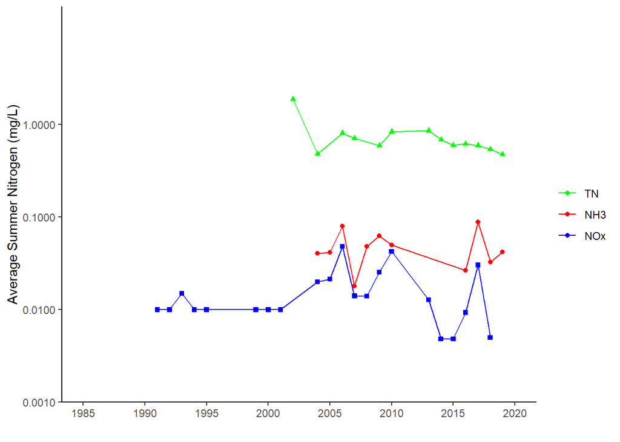

#### TN : TP

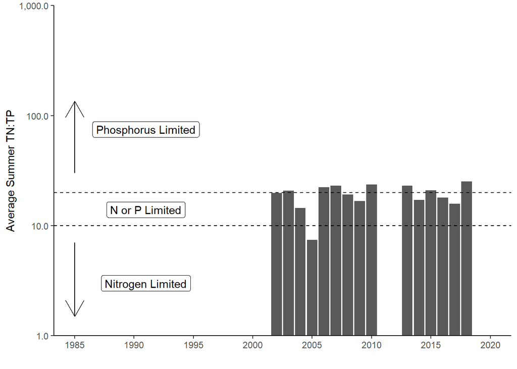

#### pH

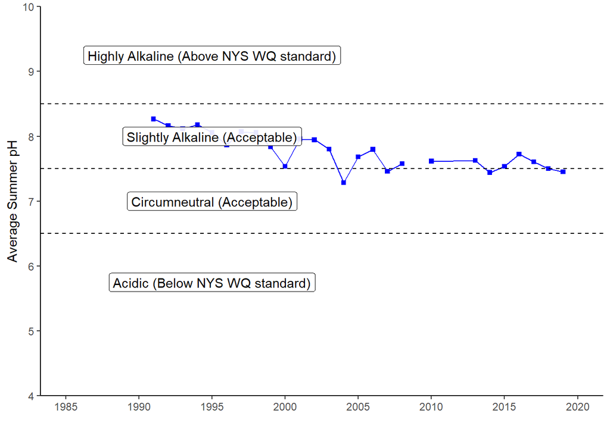

#### Specific Conductance

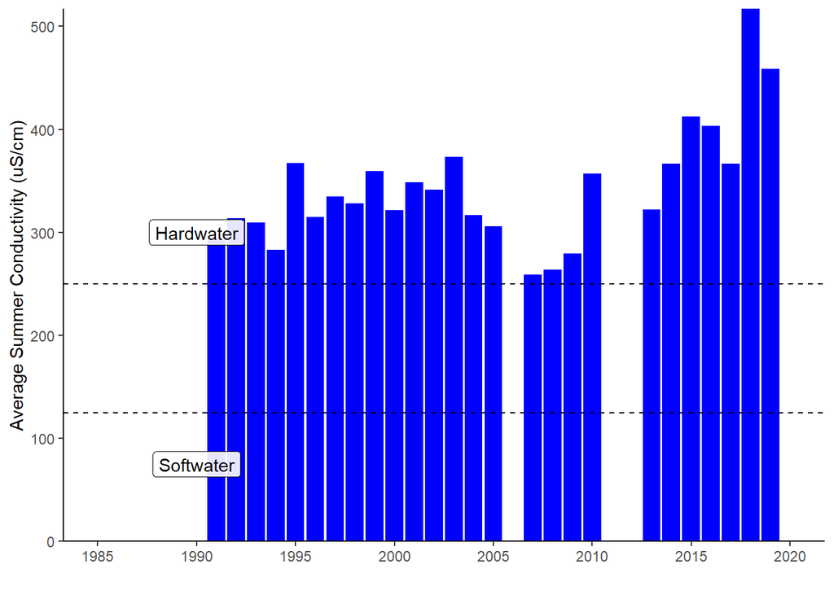

#### Calcium

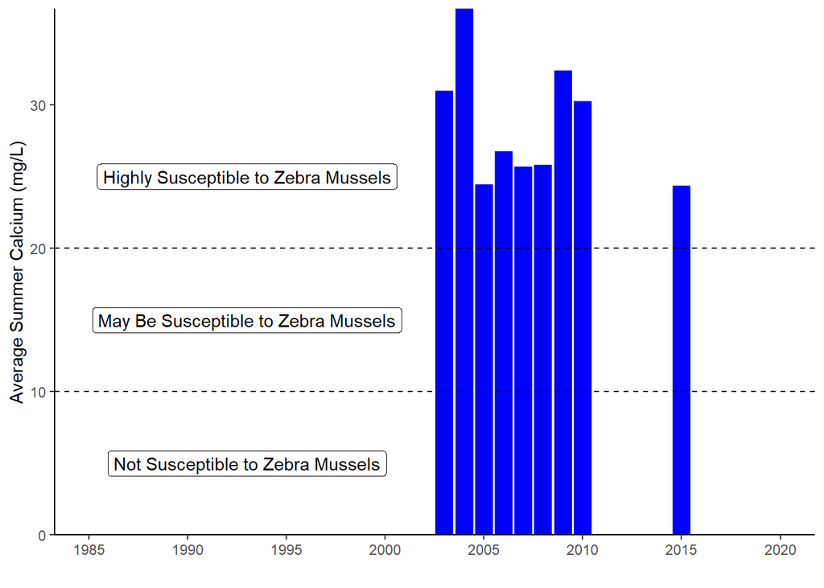

#### Chloride

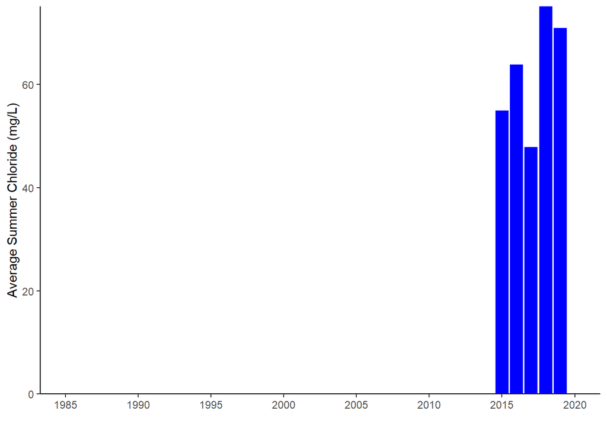

#### Color

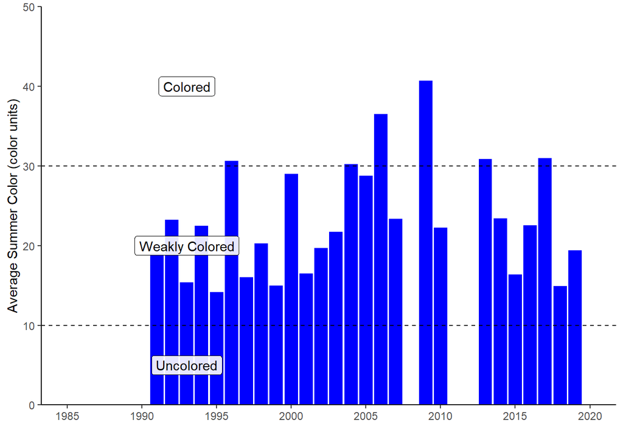

#### Surface and Deep Temperature

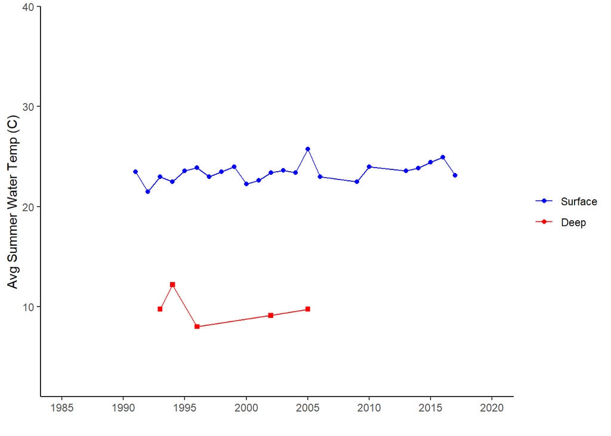

#### Lake Perception

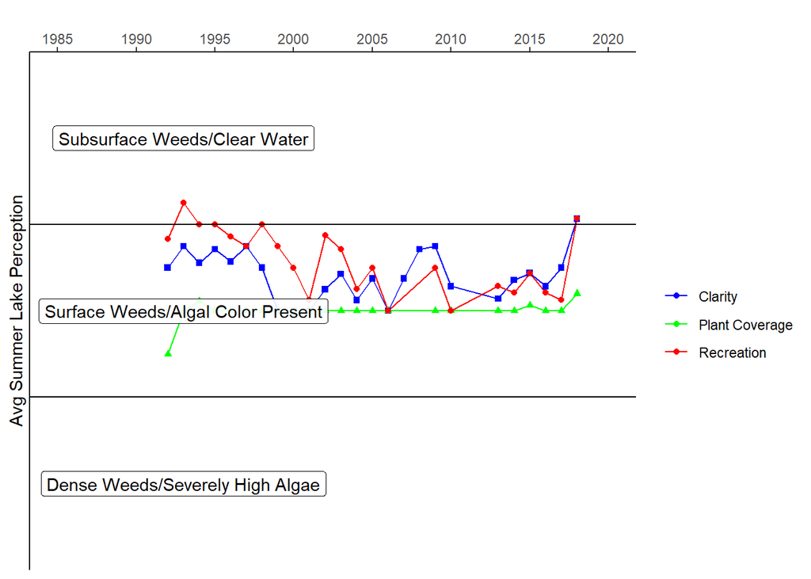

## Ballston Lake - In-Season Analysis

#### In Season Water Clarity

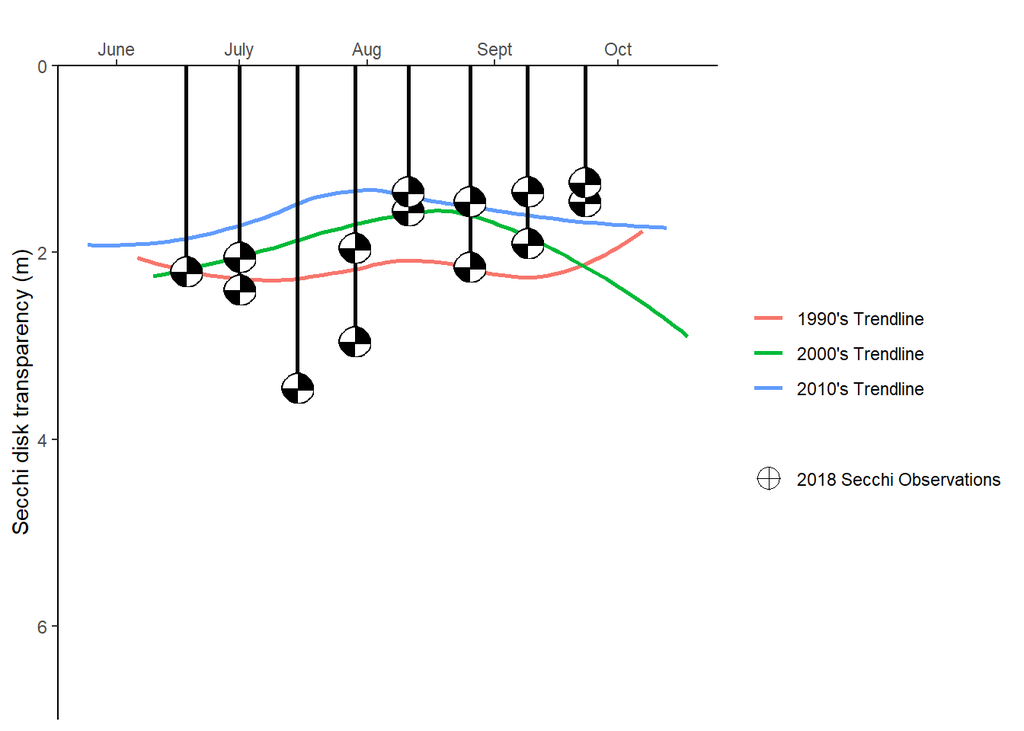

#### In Season Water Temperature

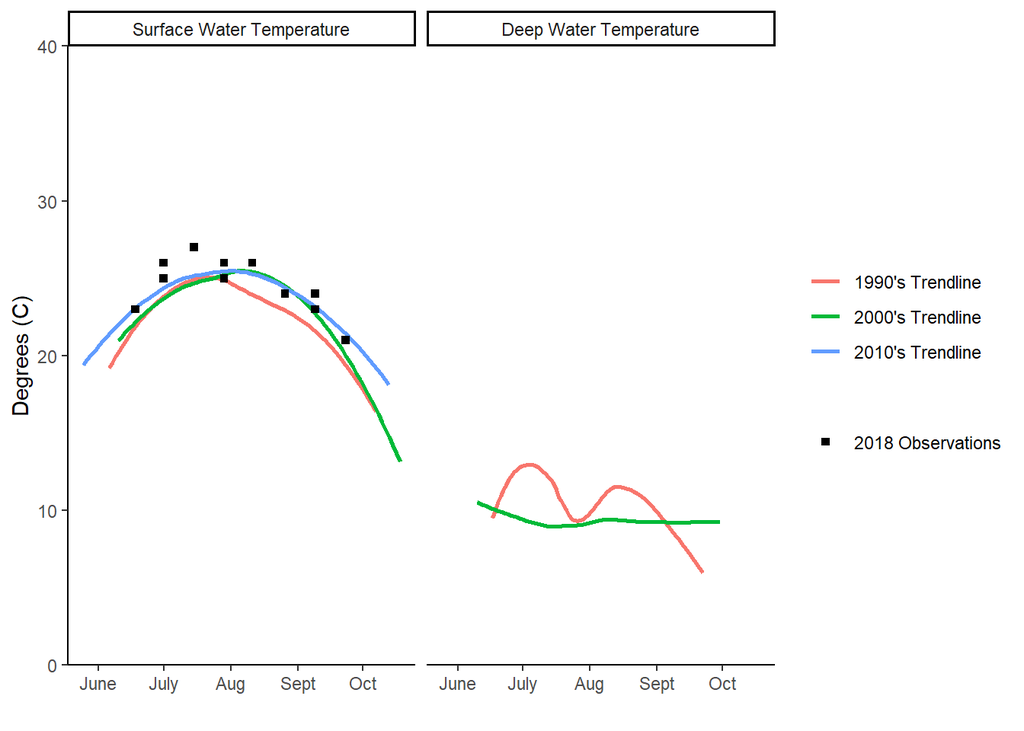

### Ballston Lake – Lake Scorecard

```
## [1] 1
```

```
## [1] 1
```

[output not shown]

| Aquatic Invasive Species | Present |
| --- | --- |